# Problem Plecakowy - implementacja w R

Maciej Paluch

05.05.2021

## Wstęp

**Problem Plecakowy** (ang. Knapsack Problem) jest jednym z najbardziej znanych problemów optymalizacyjnych. Nazwa tego problemu pochodzi od plecaka, do którego wpakowuje się przedmioty (o znanych parametrach takich jak waga (masa), a także wartość (np. cena przedmiotu)),  
w taki sposób, aby wartość sumaryczna wszystkich wpakowanych przedmiotów była jak największa. Plecak ma oczywiście swoją ładowność, której sumaryczna waga wpakowywanych przedmiotów nie może przekroczyć.

Problem też często jest nazywany problemem złodzieja. Wyobraźmy sobie zamaskowanego człowieka, który wchodzi z torbą do sklepu i chce sobie „szybko dorobić”. Zna wszystkie wartości przedmiotów na wystawie i musi zaplanować w jaki sposób pakować, aby wynieść przedmioty o jak największej wartości, ale pamiętając, że torba/plecak ma swoją maksymalną ładowność i kiedy ją przekroczy torba np. pęknie.

Dlatego celem złodzieja jest wyniesienie takich przedmiotów, które są najbardziej opłacalne pod względem sumarycznej wartości, ale uważając  
i nieprzekraczając dostępnej ładowności plecaka.

Problem plecakowy możemy rozwiązać za pomocą pewnych algorytmów:

- Algorytmy zachłanne
  - Największe Wartości
  - Najlżejsze
  - Jednostkowe (Wartość / Waga)
- Algorytm optymalny

Wygenerujmy 70 obiektów na których będziemy przeprowadzać operacje algorytmiczne:

```r
## Dane wstepne ----
## Generowanie losowych param. czasu (wagi)
time_attack <- round(abs((rnorm(70)*50))+1,0)

time_attack
```

```
##  [1]  11  38  21   8  40   9  44  37   8  46  43  29  53   4  67  47  38  35  27
## [20]  29  35  46 102   9  43  28   3  28  37  76  23  11  23  84   7 126  67  49
## [39]   4  11  25  41  16  38  30  15  78  28   5  51 139  30  63   7  47  10   4
## [58]  60  65  44  10   8  91   8  37   4  47  59  63  12
```

```r
## Generowanie losowych param. czasu (wagi)
value <- round(abs(time_attack*rnorm(35)*10)+1,0)

## Tablica z wartoscia i "waga"
data_frame <- data.frame(value,time_attack)

## Generowanie nazw przedmiotow
name_attack <- c()

for (i in 1:nrow(data_frame)){

  if (data_frame$time_attack[i] <= 15){
  name_attack[i] <- paste0("Wioska_",i)
  }

  else if (data_frame$time_attack[i] > 15  &  data_frame$time_attack[i] <= 60) {
    name_attack[i] <- paste0("Magazyn_",i)
  }

  else {
    name_attack[i] <- paste0("Twierdza_",i)
  }
}

## Ostateczna wersja tablicy z danymi
data_frame <- cbind(data_frame,name_attack)
data_frame <- data_frame[c(3,1,2)]

data_frame$name_attack <- as.character(data_frame$name_attack)
```

Sprawdźmy teraz naszą gotową ramkę danych:

```r
datatable(data_frame)
```

|  | name_attack | value | time_attack |
| --- | --- | --- | --- |
| 1 | Wioska_1 | 139 | 11 |
| 2 | Magazyn_2 | 97 | 38 |
| 3 | Magazyn_3 | 193 | 21 |
| 4 | Wioska_4 | 6 | 8 |
| 5 | Magazyn_5 | 155 | 40 |
| 6 | Wioska_6 | 45 | 9 |
| 7 | Magazyn_7 | 221 | 44 |
| 8 | Magazyn_8 | 195 | 37 |
| 9 | Wioska_9 | 55 | 8 |
| 10 | Magazyn_10 | 662 | 46 |

[output cut: 60 more lines]

## Korelacja

Sprawdźmy jaka jest korelacja pomiędzy wartością obiektu, a czasem ataku (chcemy uniknąć trywialności zadania)

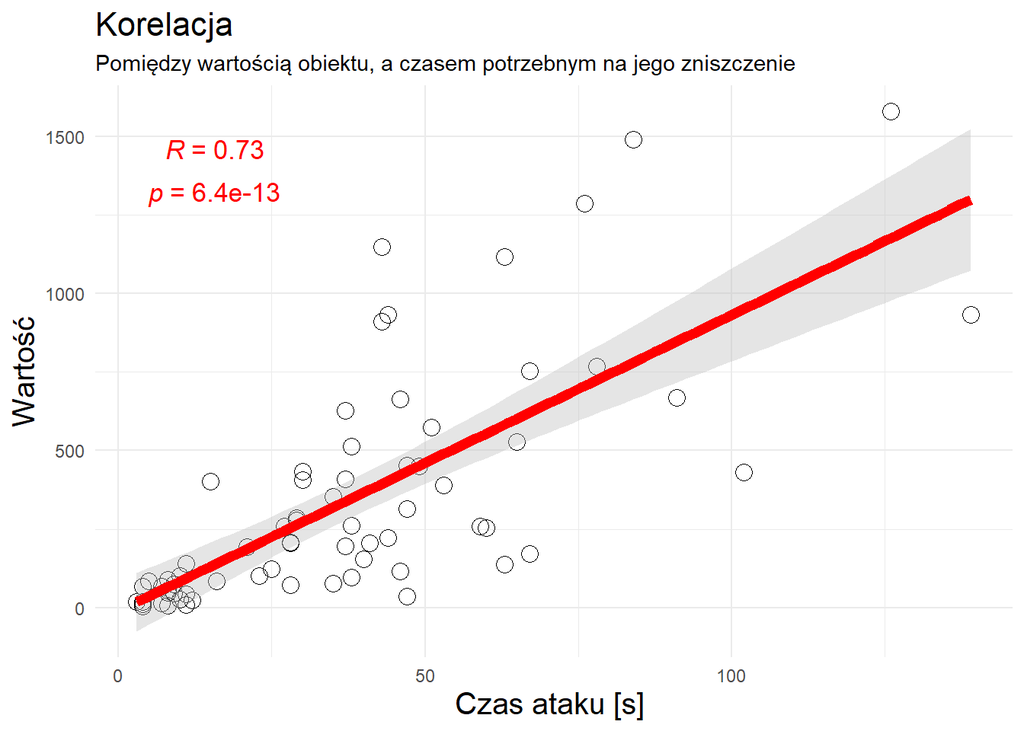

```r
ggscatter(na.omit(data_frame), y = "value", x = "time_attack",
          color = "black", size = 3.75, shape = 1,
          add = "reg.line", xlab = "Czas ataku [s] ", ylab="Wartość",
          cor.method = "pearson",
          add.params = list(color = "red", fill = "grey", size=2.4),
          conf.int = TRUE, cor.coef = TRUE,
          cor.coeff.args = list(method = "pearson", color="red", size=4.65, label.x=5, label.sep = "\n")) +
  theme_minimal() +
  #theme(panel.background = element_rect(fill="#330066")) +
  theme(plot.title = element_text(size= 16, colour= "black")) +
  theme(axis.title.x = element_text(size = 15)) +
  theme(axis.title.y = element_text(size = 15)) +
  labs(title = "Korelacja", subtitle = "Pomiędzy wartością obiektu, a czasem potrzebnym na jego zniszczenie")
```

## Algorytmy zachłanne

### Algorytm pierwszy (bierzemy pod uwagę tylko wartość)

```r
## a) Najwartosciowsze ----

## Sortujemy po wartosci najcenniejszej
value_function <- function(seconds){
  sort_val <- data_frame[order(-data_frame$value),]

  ## Obliczenie sumy sekund
  sum_time <- 0
  for (i in 1:nrow(sort_val)){
    sum_time <- sum_time + sort_val$time_attack[i]
    if (seconds <= sort_val$time_attack[1]) {
      return(0)
    }
    else if (sum_time >= seconds){
      sum_time <- sum_time - sort_val$time_attack[i]
      value_table <<- sort_val[(1:(i-1)),]
      break
    }
  }

print(ggplot(value_table, aes(cumsum(time_attack), cumsum(value))) +
        geom_step(aes(x= cumsum(time_attack), y = cumsum(value)), color="black") +
        geom_point(aes(x= cumsum(time_attack), y = cumsum(value)), size=4) +
        geom_point(aes(x=0,y=0),size= 4) +
        geom_segment(aes(x = 0, y = 0, xend = time_attack[1], yend = 0)) +
        geom_segment(aes(x = time_attack[1], y = 0, xend = time_attack[1], yend = value[1])) +
        geom_label_repel(aes(label=name_attack), size = 4) +
        labs(title= "Algorytm Zachłanny\n(Najwartościowsze)",
             x="Skumulowany czas [s]", y= "Skumulowana wartość") +
        theme_light())

return(cat(paste0("Optymalnie mozna wybrac: ", "\n",
                              paste0(as.vector(value_table$name_attack), collapse = ", "), ",",
                               "\n","gdzie laczna wartosc to: ", sum(value_table$value),
                               "\n","a potrzebny czas to: ", sum_time, "s\n\n")))

}
```

Wykorzystajmy teraz naszą funkcję dla algorytmu zachłannego pierwszego - jako argument podajemy maksymalny czas ataku (“ładowność plecaka”)

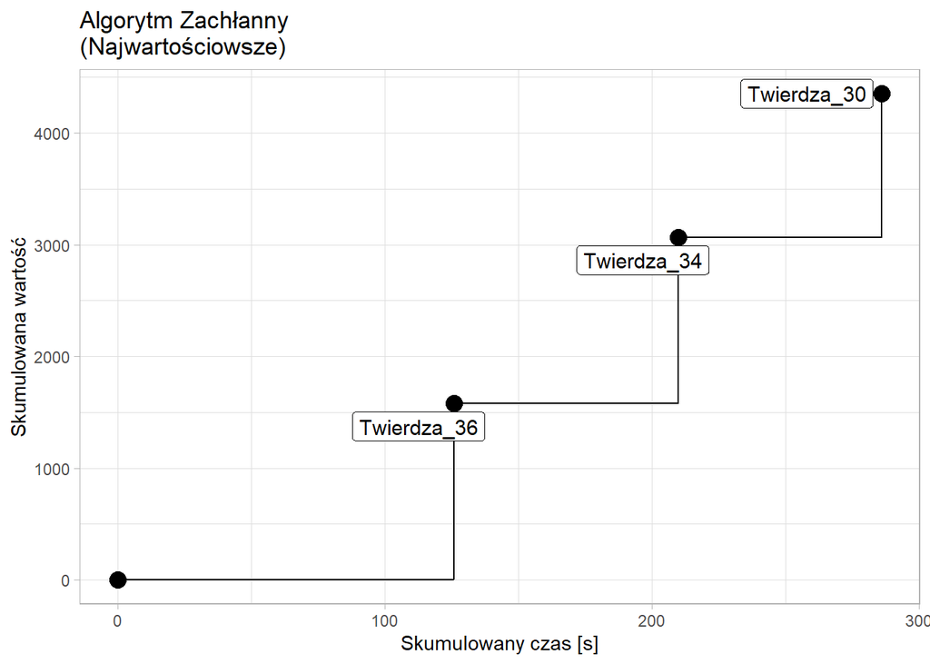

```
## Optymalnie mozna wybrac:
## Twierdza_36, Twierdza_34, Twierdza_30,
## gdzie laczna wartosc to: 4354
## a potrzebny czas to: 286s
```

|  | name_attack | value | time_attack |
| --- | --- | --- | --- |
| 36 | Twierdza_36 | 1578 | 126 |
| 34 | Twierdza_34 | 1489 | 84 |
| 30 | Twierdza_30 | 1287 | 76 |

```r
value_function(300) #Algorytm zachlanny (najwartosciowsze)
```

### Algorytm ten drugi (“Najlżejszy”)

```r
#b) Najmniej czasochlonne ----
time_function <- function(seconds){
sort_time <- data_frame[order(data_frame$time_attack),]

sum_time <- 0
for (i in 1:nrow(sort_time)){
  sum_time <- sum_time + sort_time$time_attack[i]
  if (seconds <= sort_time$time_attack[1]) {
    return(0)
  }
  else if (sum_time >= seconds){
    sum_time <- sum_time - sort_time$time_attack[i]
    time_table <<- sort_time[(1:(i-1)),]
    break
  }
}

print(ggplot(time_table, aes(cumsum(time_attack), cumsum(value))) +
        geom_step(aes(x= cumsum(time_attack), y = cumsum(value)), color="black") +
        geom_point(aes(x= cumsum(time_attack), y = cumsum(value)), size=4) +
        geom_point(aes(x=0,y=0),size= 4) +
        geom_segment(aes(x = 0, y = 0, xend = time_attack[1], yend = 0)) +
        geom_segment(aes(x = time_attack[1], y = 0, xend = time_attack[1], yend = value[1])) +
        geom_label_repel(aes(label=name_attack), size = 4) +
        labs(title= "Algorytm Zachłanny\n(Najmniej czasochłonne)",
             x="Skumulowany czas [s]", y= "Skumulowana wartość") +
        theme_light())



return(cat(paste0("Optymalnie mozna wybrac: ", "\n",
                            paste0(as.vector(time_table$name_attack), collapse = ", "), ",",
                            "\n","gdzie laczna wartosc to: ", sum(time_table$value),
                            "\n","a potrzebny czas to: ", sum_time, "s\n\n")))

}
```

Wykorzystajmy teraz naszą funkcję dla algorytmu zachłannego drugiego - jako argument podajemy maksymalny czas ataku (“ładowność plecaka”)

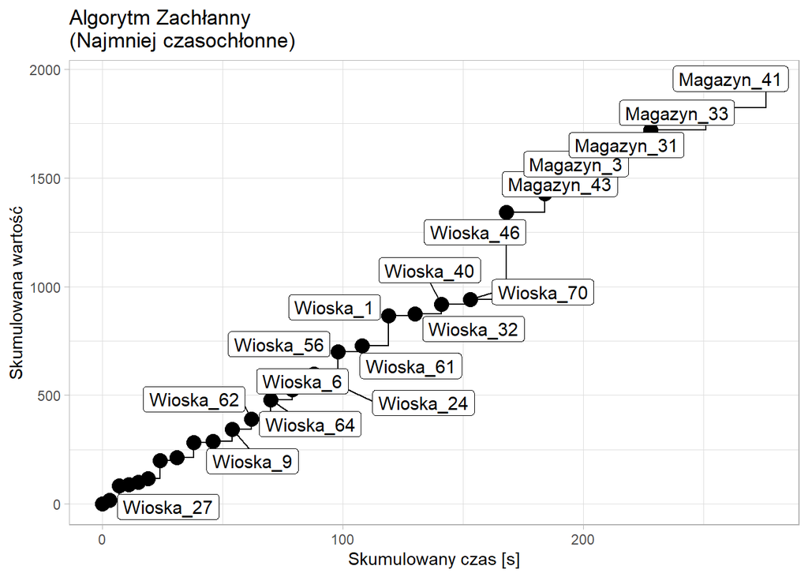

```
## Optymalnie mozna wybrac:
## Wioska_27, Wioska_14, Wioska_39, Wioska_57, Wioska_66, Wioska_49, Wioska_35, Wioska_54, Wioska_4, Wioska_9, Wioska_62, Wioska_64, Wioska_6, Wioska_24, Wioska_56, Wioska_61, Wioska_1, Wioska_32, Wioska_40, Wioska_70, Wioska_46, Magazyn_43, Magazyn_3, Magazyn_31, Magazyn_33, Magazyn_41,
## gdzie laczna wartosc to: 1945
## a potrzebny czas to: 276s
```

|  | name_attack | value | time_attack |
| --- | --- | --- | --- |
| 27 | Wioska_27 | 18 | 3 |
| 14 | Wioska_14 | 67 | 4 |
| 39 | Wioska_39 | 4 | 4 |
| 57 | Wioska_57 | 11 | 4 |
| 66 | Wioska_66 | 18 | 4 |
| 49 | Wioska_49 | 83 | 5 |
| 35 | Wioska_35 | 14 | 7 |
| 54 | Wioska_54 | 68 | 7 |
| 4 | Wioska_4 | 6 | 8 |
| 9 | Wioska_9 | 55 | 8 |

[output cut: 16 more lines]

```r
time_function(300) #Algorytm zachlanny ("najlzejsze")
```

### Algorytm zachłanny trzeci (jednostkowy):

```r
##c) Jednostkowe----
unit_function <- function(seconds){

## Tablica z podzielona wartoscia na 1 sekunde ataku
sort_unit <- data_frame[order(-data_frame$value),]
unit_sec <- round(c(sort_unit$value/sort_unit$time_attack),3)
sort_unit <- cbind(sort_unit, unit_sec)
sort_unit <- sort_unit[order(-sort_unit$unit_sec),]

sum_time <- 0
for (i in 1:nrow(sort_unit)){
  sum_time <- sum_time + sort_unit$time_attack[i]
  if (seconds <= sort_unit$time_attack[1]) {
    return(0)
  }
  else if (sum_time >= seconds){
    sum_time <- sum_time - sort_unit$time_attack[i]
    unit_table <<- sort_unit[(1:(i-1)),]
    break
  }
}

print(ggplot(unit_table, aes(cumsum(time_attack), cumsum(value))) +
        geom_step(aes(x= cumsum(time_attack), y = cumsum(value)), color="black") +
        geom_point(aes(x= cumsum(time_attack), y = cumsum(value)), size=4) +
        geom_point(aes(x=0,y=0),size= 4) +
        geom_segment(aes(x = 0, y = 0, xend = time_attack[1], yend = 0)) +
        geom_segment(aes(x = time_attack[1], y = 0, xend = time_attack[1], yend = value[1])) +
        geom_label_repel(aes(label=name_attack), size = 4) +
        labs(title= "Algorytm Zachłanny\n(Wartość/Waga) ",
             x="Skumulowany czas [s]", y= "Skumulowana wartość") +
        theme_light())

return(cat(paste0("Optymalnie mozna wybrac: ", "\n",
                         paste0(as.vector(unit_table$name_attack), collapse = ", "), ",",
                         "\n","gdzie laczna wartosc to: ", sum(unit_table$value),
                         "\n","a potrzebny czas to: ", sum_time, "s\n\n")))

}
```

Wykorzystajmy teraz naszą funkcję dla algorytmu zachłannego trzeciego - jako argument podajemy maksymalny czas ataku (“ładowność plecaka”)

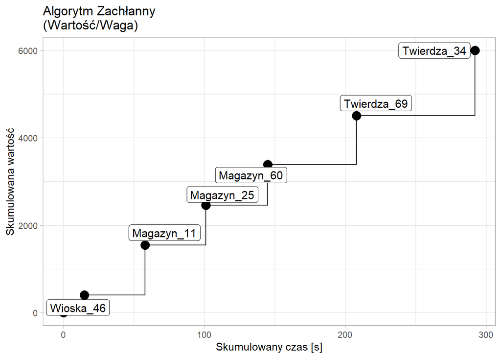

```
## Optymalnie mozna wybrac:
## Wioska_46, Magazyn_11, Magazyn_25, Magazyn_60, Twierdza_69, Twierdza_34,
## gdzie laczna wartosc to: 5998
## a potrzebny czas to: 292s
```

|  | name_attack | value | time_attack | unit_sec |
| --- | --- | --- | --- | --- |
| 46 | Wioska_46 | 401 | 15 | 26.733 |
| 11 | Magazyn_11 | 1148 | 43 | 26.698 |
| 25 | Magazyn_25 | 911 | 43 | 21.186 |
| 60 | Magazyn_60 | 932 | 44 | 21.182 |
| 69 | Twierdza_69 | 1117 | 63 | 17.73 |
| 34 | Twierdza_34 | 1489 | 84 | 17.726 |

```r
unit_function(300)#Algorytm zachlanny (wartosc/waga)
```

## Algorytm optymalny

```r
##2) Algorytm optymalny ----
optim_function <- function(w, p, cap) {
  n <- length(w)

  # macierze
  x <- logical(n)
  Fr <- matrix(0, nrow = cap + 1, ncol = n)
  G <- matrix(0, nrow = cap + 1, ncol = 1)

  # uzupelnienie macierzy wartosciami
  for (k in 1:n) {
    Fr[, k] <- G
    H <- c(numeric(w[k]), G[1:(cap + 1 - w[k]), 1] + p[k])
    G <- pmax(G, H)
  }
  fmax <- G[cap + 1, 1]

  # wyszukiwanie nazw
  f <- fmax
  j <- cap + 1
  for (k in n:1) {
    if (Fr[j, k] < f) {
      x[k] <- TRUE
      j <- j - w[k]
      f <- Fr[j, k]
    }
  }

  inds <- which(x)
  wght <- sum(w[inds])
  prof <- sum(p[inds])
  names_list <- c()
  v <- as.vector(inds)
  v_leng <- as.numeric(length(v))

  for (i in 1:v_leng){
    names_list[i] <- (data_frame[v[i],1])
    knap_table <<- data_frame[v,]
  }

print(ggplot(knap_table, aes(cumsum(time_attack), cumsum(value))) +
  geom_step(aes(x= cumsum(time_attack), y = cumsum(value)), color="black") +
  geom_point(aes(x= cumsum(time_attack), y = cumsum(value)), size=5) +
  geom_point(aes(x=0,y=0),size= 5) +
  geom_segment(aes(x = 0, y = 0, xend = time_attack[1], yend = 0)) +
  geom_segment(aes(x = time_attack[1], y = 0, xend = time_attack[1], yend = value[1])) +
  geom_label_repel(aes(label=name_attack), size = 4) +
  labs(title= "Algorytm Optymalny", x="Skumulowany czas [s]", y= "Skumulowana wartość") +
  theme_light())

return(cat(paste0(" Optymalnie mozna wybrac: ", "\n",
                           paste0(as.vector(names_list), collapse = ", "), ",",
                           "\n\n","gdzie laczna wartosc to: ", prof,
                           "\n","a potrzebny czas to: ", wght, "s\n\n")))

}
```

Wykorzystajmy teraz naszą funkcję dla algorytmu optymalnego - w argumentach podajemy dwie interesujące nas zmienne, oraz maksymalny czas ataku (“ładowność plecaka”)

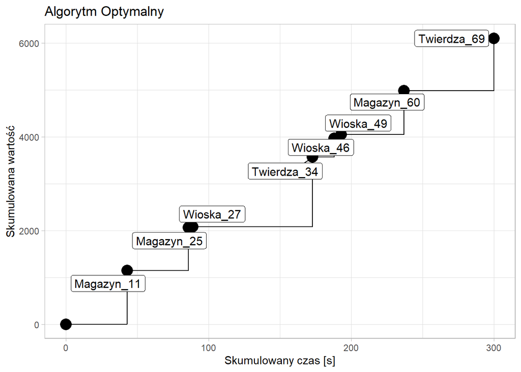

```
##  Optymalnie mozna wybrac:
## Magazyn_11, Magazyn_25, Wioska_27, Twierdza_34, Wioska_46, Wioska_49, Magazyn_60, Twierdza_69,
##
## gdzie laczna wartosc to: 6099
## a potrzebny czas to: 300s
```

|  | name_attack | value | time_attack |
| --- | --- | --- | --- |
| 11 | Magazyn_11 | 1148 | 43 |
| 25 | Magazyn_25 | 911 | 43 |
| 27 | Wioska_27 | 18 | 3 |
| 34 | Twierdza_34 | 1489 | 84 |
| 46 | Wioska_46 | 401 | 15 |
| 49 | Wioska_49 | 83 | 5 |
| 60 | Magazyn_60 | 932 | 44 |
| 69 | Twierdza_69 | 1117 | 63 |

```r
optim_function(data_frame$time_attack, data_frame$value, 300) #Algorytm optymalny
```

```r
##3) Wykres porownujacy ----
all_plot_function <- function(){
print(ggplot() +
  geom_step(data=time_table,aes(x=cumsum(time_attack), y=cumsum(value)), color="black") +
  geom_point(data=time_table,aes(x=cumsum(time_attack), y=cumsum(value)), size=2, color="black") +
  geom_point(data=time_table, aes(x=0,y=0, colour="black"),size=2) +
  geom_segment(data=time_table, aes(x=0, y=0, xend=time_attack[1], yend=0), color="white") +
  geom_segment(data=time_table, aes(x=time_attack[1], y=0, xend=time_attack[1], yend=value[1]),
               color= "black") +

  geom_step(data=unit_table,aes(x=cumsum(time_attack), y=cumsum(value)), color="green") +
  geom_point(data=unit_table,aes(x=cumsum(time_attack), y=cumsum(value)), size=2, color="green") +
  geom_point(data=unit_table, aes(x=0,y=0, colour="green"),size=2) +
  geom_segment(data=unit_table, aes(x=0, y=0, xend=time_attack[1], yend=0), color="green") +
  geom_segment(data=unit_table, aes(x=time_attack[1], y=0, xend=time_attack[1], yend=value[1]),
               color= "green") +

  geom_step(data=value_table,aes(x=cumsum(time_attack), y=cumsum(value)), color="royalblue2") +
  geom_point(data=value_table,aes(x=cumsum(time_attack), y=cumsum(value)), size=2, color="royalblue2") +
  geom_point(data=value_table, aes(x=0,y=0, colour="royalblue2"),size=2) +
  geom_segment(data=value_table, aes(x=0, y=0, xend=time_attack[1], yend=0), color="royalblue2") +
  geom_segment(data=value_table, aes(x=time_attack[1], y=0, xend=time_attack[1], yend=value[1]),
               color= "royalblue2") +

  geom_step(data=knap_table,aes(x=cumsum(time_attack), y=cumsum(value)), color="red") +
  geom_point(data=knap_table,aes(x=cumsum(time_attack), y=cumsum(value)), size=2, color="red") +
  geom_point(data=knap_table, aes(x=0,y=0, colour="red"),size=2) +
  geom_segment(data=knap_table, aes(x=0, y=0, xend=time_attack[1], yend=0), color="red") +
  geom_segment(data=knap_table, aes(x=time_attack[1], y=0, xend=time_attack[1], yend=value[1]),
               color="red") +

  geom_point(data=knap_table, aes(x=0,y=0),size=3.5, shape=8) +

  scale_color_manual(labels=c("Najlżejszy", "Wartość", "Wartość / Waga", "Optymalny"),
                     values = c("black", "royalblue2", "green", "red")) +
  labs(title= "Porównanie Algorytmów", x= "Skumulowany czas [s]", y= "Skumulowana wartość",
       color= "Algorytm: ") +
  theme_light())
}
```

Wykorzystajmy funkcję do wygenerowania porównującego wykresu (nie musimy podawać żadnych argumentów)

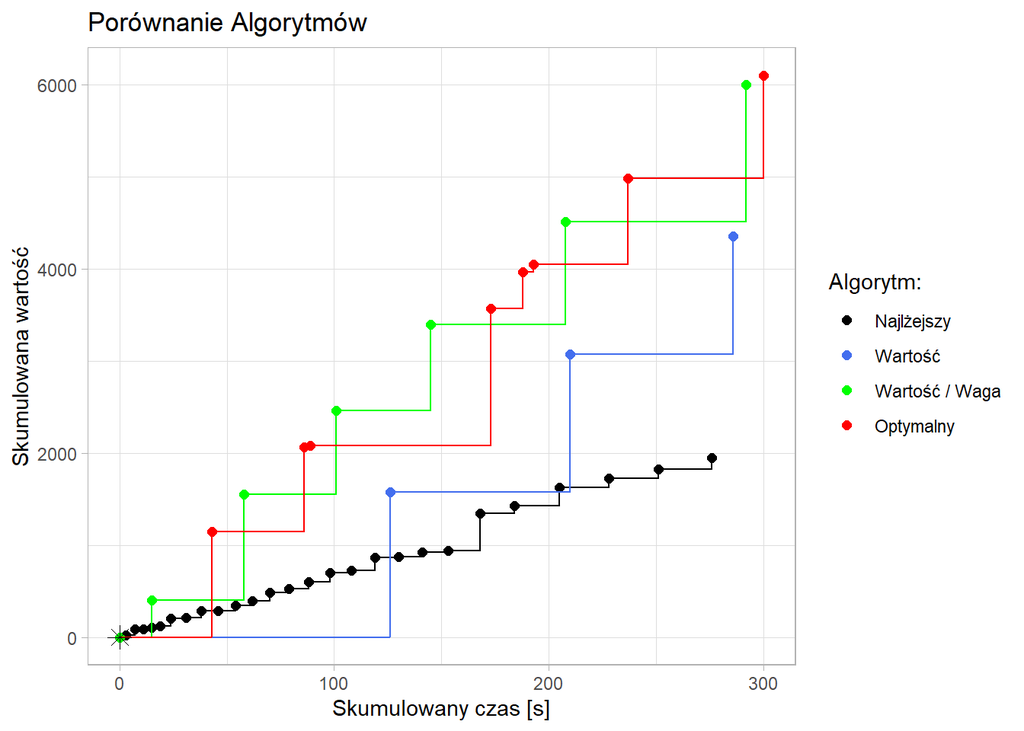

```r
all_plot_function()
```